# Assignment 4: Cicada emergence

Xiyu Zhang

2022-10-01

## Overview

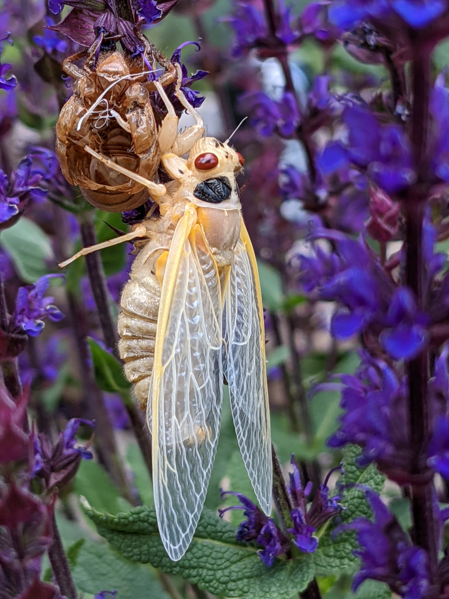

In the spring of 2021, the Brood X cicadas emerged throughout much of the Mid-Atlantic region. Brood X are periodical cicadas that spend most of their lives underground, emerge in the spring every 17 years, breed, and then die. In their adult form, they produce an incredibly loud song to attract mates.

Our team at the Smithsonian deployed automated sound recording units (ARUs) throughout the District of Columbia, Maryland, and Virginia. Our goal for this study was to determine how bird song may vary in response to cicada noise along a gradient of anthropogenic noise and urban intensity.

In this exercise, you will explore cicada observations collected by iNaturalist community science participants. Early reports by iNaturalist observers helped us to determine the appropriate locations to place our ARUs.

When I create an R Markdown file to communicate a coding process, I usually work in a .R script file and copy-and-paste the code into the R Markdown document at the end.

**Important**

To receive full credit for a given question, please ensure that the result you provide **only** answers the given question. For example, in the table below, if you were asked to determine the value in column `b` where column `a` is equal to “hello” you would provide the following code:

```r
tibble(
  a = c('hello', 'world'),
  b = 1:2) %>%
  filter(a == 'hello') %>%
  pull(b)
```

```
## [1] 1
```

## Grading

The points allotted for each question are provided in highlighted red bold text (e.g., [1.0]) within the question itself. When applicable, total points for a question may represent the sum of individually graded components, which are provided in red text (e.g., [1.0]).

**Points may be deducted from each question’s total:**

*Note: The maximum deduction is the total points value for a given question*

You must ensure that your R Markdown document **runs out-of-the-box** – in other words, the document will knit without error. Some tips for doing so:

- Do not maintain your project folder in a location that is backed up by an online directory (e.g., Dropbox, iCloud)
- Ensure that all file paths are equivalent to those in this document (e.g., in `source()` or `read_csv()`)
- Do not use `setwd()` in your code (**Never** use `setwd()`!)
- If one of your code chunks contains an error, include `eval = FALSE` in the options for that chunk
- Prior to submission, clear all objects from your global environment prior to knitting your R Markdown document

In this assignment, you may use **only** the following R functions (*Note: If you are unclear on what a given function does, use `?` to view the help file!*):

- base::<-
- base::=
- base:: ::
- base::(
- base::)
- base::==
- base::%in%
- base::c
- base::library
- base::min
- base::names
- base::rm
- base::tolower
- dplyr::arrange
- dplyr::filter
- dplyr::group_by
- dplyr::full_join
- dplyr::inner_join
- dplyr::mutate
- dplyr::n
- dplyr::select
- dplyr::summarize
- ggplot2::aes
- ggplot2::geom_sf
- ggplot2::ggplot
- ggplot2::scale_fill_viridis_c
- ggplot2::theme_set
- ggplot2::theme_void
- kableExtra::kable
- kableExtra::kable_styling
- magrittr::%>%
- readr::read_csv
- rlang::set_names
- sf::st_as_sf
- sf::st_crs
- sf::st_filter
- sf::st_join
- sf::st_read
- sf::st_transform
- tibble::as_tibble

*Note: The packages dplyr, ggplot2, magrittr, readr, rlang, and tibble are all part of the tidyverse and are loaded with `library(tidyverse)`.*

## Getting started

Open R Studio. Please ensure that the Global Options for R Markdown are set to “Show output preview in Viewer Pane”. This will allow you to view the knitted document (i.e., the html version of this file) right next to your code.

As always, please ensure that you are starting with a clean session. Please do the following before continuing:

- If there are any script files open in your source pane. Close them. If any of the file titles are blue, save them prior to closing.
- In the *Environment* tab of your **workspace pane**, ensure that your **global environment** is empty. If it is not, click the *broom* to remove all objects.
- In the *History* tab of your **workspace pane**, ensure that your history is empty. If it is not, click the *broom* to remove your history.

1. [0.5] Save and knit this document:

- Replace my name in the YAML header with yours [0.1]
- Add the current date in the YAML header [0.1]
- Save the *.rmd* file in the **output** folder of your project as (*but replace my name with yours*): `assignment_4_Evans_Brian.rmd` [0.3]

## The setup

**All** of my scripts start with a setup section where I load libraries, set session options, conduct initial data loading, and early processing steps.

2. [0.5] Load the `sf`, `lubridate`, and `tidyverse` libraries.

```r
# Load libraries

library(sf)
library(lubridate)
library(tidyverse)
```

3. [0.5] Set the theme of *all* of the plots in this document to `theme_void()`.

```r
# Set the theme of all plots

theme_set(
  new = theme_void())
```

4. [1.0] Read in and process the file `cicadas_brood_x_2021.csv`. In doing so:

- [0.25] Load the data as a tibble;
- [0.25] Subset the data to where the quality grade is classified as “research”;
- [0.25] Subset the data to the fields `datetime`, `scientific_name`, `user`, `longitude`, and `latitude`;
- [0.25] Assign the data to your global environment with the name `cicadas_temp`.

```r
# read in and process cicadas data

# assign the data to global environment with the specific name

cicadas_temp <-

  # load the data as a tibble

  read_csv('data/raw/cicadas_brood_x_2021.csv') %>%

  # subset the data where the quality grade is 'research'

  filter(quality_grade == 'research') %>%

  # subset the data to the fields datetime, scientific_name,
  # user, longitude, and latitude

  select(datetime, scientific_name, user, longitude, latitude)
```

5. [1.0] Read and processes the file `counties.geojson` (*or `counties_low_res.geojson` if you have memory issues!*). In doing so:

- [0.25] Load the data into your global environment as a simple features shapefile;
- [0.25] Convert all field names to lowercase;
- [0.25] Transform the Coordinate Reference System (CRS) of the object to EPSG 2283 (a CRS often used for Virginia);
- [0.25] Assign the name `counties_temp` to the resultant object.

```r
# Read in and process counties data

# assign the data to global environment with the specific name

counties_temp <-

  # load the data as a simple features shapefile

  st_read('data/raw/shapefiles/counties.geojson') %>%

  # convert all field name to lowercase

  set_names(

    # extract the name of this data set

    names(.) %>%

      # convert it into lowercase

      tolower()) %>%

  # transform the CRS to EPSG 2283

  st_transform(crs = 2283)
```

## Subsetting data

### About the data

The `cicadas_temp` file represents research-grade iNaturalist observations of Brood X periodical cicadas from February through September of 2021. These data contain the following fields:

- `datetime`: The date and time of the observation, formatted as an ISO 8601 (yyyy-mm-dd hh:mm:ss) datetime object and reported in UTC;
- `scientific_name`: The genus and species of the observed cicada;
- `user`: The user’s login name;
- `place_guess`: Best guess for the location of the observation;
- `longitude`: The longitude of an observation, recorded in EPSG 4326;
- `latitude`: The latitude of an observation, recorded in EPSG 4326;
- `image_url`: The address of the image online;
- `quality_grade`: Whether the species identification can be trusted, based on expert opinion – options include “casual”, “needs_id”, and “research” (verified by experts);
- `description`: Notes that users may submit with their observations.

6. [1.0] Brood X cicada are comprised of three species, *Magicicada cassinii*, *M. septendecim*, and *M. septendecula*. A large proportion of the observations (about 60%) could not be identified to species (you can explore this with `group_by()` and `summarize()`) and one of the observations was of a 13-year periodical cicada, `M. tredecim`.

- [0.25] Subset the data to Brood X cicada that could be identified to species;
- [0.5] Assign the object to your global environment with the name `cicadas_brood_x`;
- [0.25] Remove `cicadas_temp` from your global environment.

```r
# Subset the data of Brood X cicada

# assign the subset object to global environment

cicadas_brood_x <-

  # subset data in cicadas_temp that could be identified to species

  cicadas_temp %>%

  # interest observation's scientific_name should among these three

  filter(scientific_name %in%
           c('Magicicada cassinii',
             'Magicicada septendecim',
             'Magicicada septendecula'))

# remove cicadas_temp from the global environment

rm(cicadas_temp)
```

When working with spatial data, it’s often necessary to subset the **spatial extent** of your files to your study area. This will save a lot of processing time (and, potentially, help you avoid out-of-memory errors!).

7. [1.0] Subset `counties_temp` to counties in the District of Columbia, Maryland, or Virginia [0.5], assign to your global environment as `counties` [0.25], and remove `counties_temp` from your global environment [0.25].

```r
# subset counties in DMV area

# assign to global environment with specific name

counties <-

  # subset counties in DMV area

  counties_temp %>%

  # data of interest's state_name should among these three

  filter(state_name %in%
           c('District of Columbia',
             'Maryland',
             'Virginia'))

# remove counties_temp from the global environment

rm(counties_temp)
```

8. [1.5] Convert `cicadas_brood_x` to an `sf` point file [0.25 points] and subset to our area of interest. In doing so:

- [0.25] Transform the CRS of the object to the same projection as `counties`;
- [0.5] Subset the data to observations in the District of Columbia, Maryland, or Virginia;
- [0.25] Assign the name `cicadas_sf` to the resultant object;
- [0.25] Remove `cicadas_brood_x` from your global environment.

```r
# convert and subset cicadas_brood_x

# assign specific name to the subject in global environment

cicadas_sf <-

  # convert it to an sf point file

  cicadas_brood_x %>%
  st_as_sf(

    # data in 'longitude' and 'latitude' columns are coordinates

    coords = c('longitude', 'latitude'),

    # the initial CRS is EPSG 4326

    crs = 4326) %>%

  # transform the CRS to the same projection as counties

  st_transform(

    # get the CRS of counties

    st_crs(counties)) %>%

  # subset the data to observations in DMV area

  st_filter(counties)

# remove cicadas_brood_x from global environment

rm(cicadas_brood_x)
```

## Data exploration

In evaluating the distributions of Brood X for our experiment, we were interested in when each species of cicada emerged and where the most cicadas were observed.

9. [1.5] Generate a `kable` [0.25] that displays the **datetime** that each species of cicada [0.5] was **first observed** in each state [0.5]. Please arrange the table from earliest to latest datetime [0.5] (*Note: The columns of the summary table should be `state_name`, `scientific_name`, and `datetime`*).

```r
# generate a kable displaying that each species of cicada was first
# observed in each state

cicadas_sf %>%

  # conduct a spatial join based on geometry, so that get to know the state
  # of each observation

  st_join(
    counties %>%

      # focus on state-level information

      select(state_name)) %>%

  # convert the sf object into a tibble

  as_tibble() %>%

  # for observations for each species in each state

  group_by(scientific_name, state_name) %>%

  # filter the earliest time

  filter(datetime == min(datetime)) %>%

  # select the columns of interest

  select(state_name, scientific_name, datetime) %>%

  # arrange the table from earliest to latest datetime

  arrange(datetime) %>%

  # generate a kable for display

  kableExtra::kable() %>%

  # set a style of the kable

  kableExtra::kable_styling(latex_options = "striped")
```

| state_name | scientific_name | datetime |
| --- | --- | --- |
| District of Columbia | Magicicada septendecim | 2021-05-03 15:56:30 |
| Virginia | Magicicada septendecim | 2021-05-12 10:25:33 |
| Maryland | Magicicada septendecim | 2021-05-14 08:16:27 |
| Virginia | Magicicada cassinii | 2021-05-15 13:45:17 |
| Maryland | Magicicada cassinii | 2021-05-16 12:35:20 |
| Virginia | Magicicada septendecula | 2021-05-17 13:45:23 |
| Maryland | Magicicada septendecula | 2021-05-18 12:56:55 |
| District of Columbia | Magicicada cassinii | 2021-05-19 17:01:34 |
| District of Columbia | Magicicada septendecula | 2021-05-21 10:52:00 |

10. [1.5]. Generate a choropleth map of counties [0.5], where:

- [0.5] The fill color is determined by the number of cicadas that were observed in each county;
- [0.5] Counties with no observations are colored light gray.

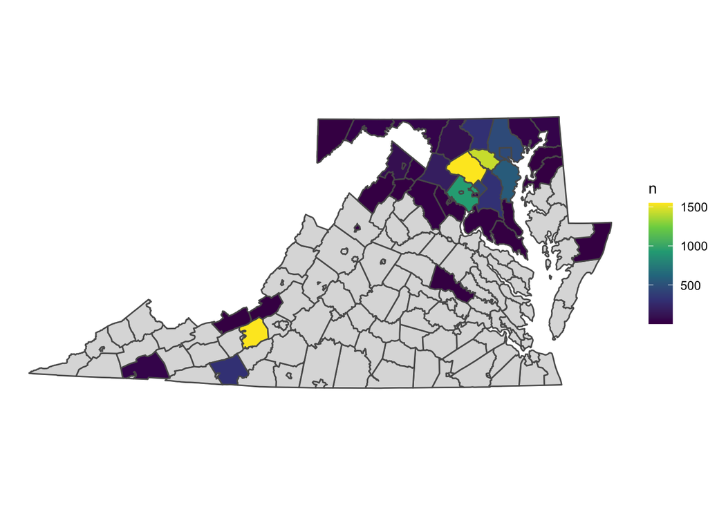

```r
# generate a choropleth map of counties visualizing the number of
# cicadas that were observed in each county

cicadas_sf %>%

  # conduct a spatial join, combine each observation with a county

  st_join(
    counties %>%

      # focus on county-level information, select county names

      select(name)) %>%

  # convert the sf object into a tibble

  as_tibble() %>%

  # in each county,

  group_by(name) %>%

  # count the total observation amount

  summarise(n = n()) %>%

  # combine the geometry information of counties with observation amounts,
  # 'counties' comes first to keep counties with NA value

  full_join(counties, .) %>%

  # generate a choropleth map

  ggplot() +

  # the fill color is determined by number of observations

  geom_sf(aes(fill = n)) +

  # set counties with no observations color as light gray

  scale_fill_viridis_c(
    na.value = '#dcdcdc')
```